# wageapp - Analyse Wage Data

July 31, 2017

## Summary

**wageapp** is built thru shiny to produce visualization of relationship between various features and wage, from the famous **Wage** data from ISLR package.

- No preprocessing was done to the data
- Some features were left out of the analysis, for example, with no variability - sex, region etc.
- Wage was compared with each of the features in a plot to visually check relationship

## Data Overview

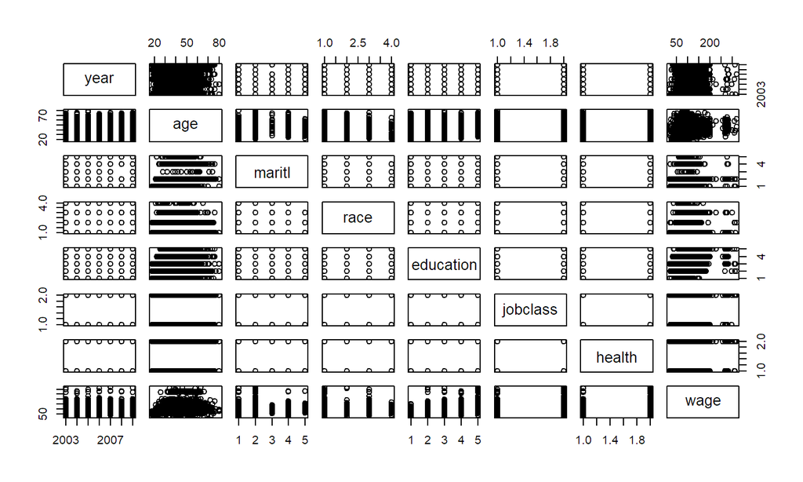

```r
library(ISLR); data("Wage");pairs(Wage[, -c(3,7,10,11)])
```

## App Idea

Real life data often includes many variables where it is not immediately clear as to which ones are integral to the analysis and which ones can be thrown away.

Before one can jump into modelling, visual analysis can help in exploration and forming ideas about the data and relationships.

While this app is built with **Wage** data alone, the approach can be replicated with other data sets.

With minor tweaks, one can repurpose this app for other datasets.

## App link

Thank you for cheking it out!

The app is hosted at shinyapps.io per link [here](https://generalinsight.shinyapps.io/wageapp/).